# Posterior Simulation & Analysis

Alicia Johnson

**Getting started**

- We have provided an `.Rmd` file for this activity: `R/02-posterior-activity.Rmd`.
- If you prefer to use an `R` file, first make sure that you’re working within your directory with the repo files, and then run the following from the Console:  
  `knitr::purl("R/02-posterior-activity.Rmd", "R/02-posterior-activity.R")`

  This will create an R file with the activity R code. For the corresponding discussion and prompts, see the `R/02-posterior-activity.html` file in the repo.
- There are some solutions that will appear in the knit html. Avoid knitting if you want to avoid solutions!

# Background

We’ll continue our analysis of $\pi$, the proportion of films that pass the Bechdel test. Let’s start with a Beta(2,2) prior model of $\pi$. Upon observing data that 9 of 20 films passed the test, our **posterior** model of $\pi$, Beta(11, 13), is shown below:

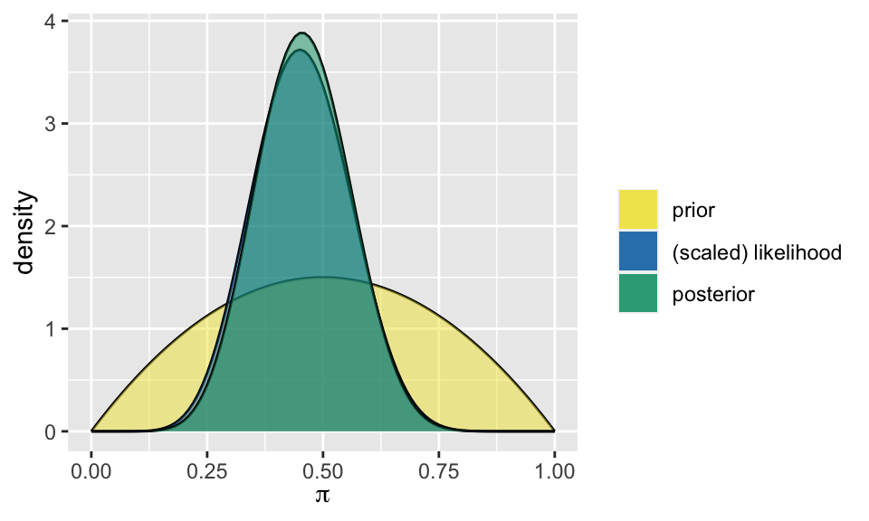

```r
library(bayesrules)
plot_beta_binomial(alpha = 2, beta = 2, y = 9, n = 20)
```

```r
summarize_beta_binomial(alpha = 2, beta = 2, y = 9, n = 20)
```

```
##       model alpha beta      mean      mode         var         sd
## 1     prior     2    2 0.5000000 0.5000000 0.050000000 0.22360680
## 2 posterior    11   13 0.4583333 0.4545455 0.009930556 0.09965217
```

Now **pretend** that we weren’t able to mathematically specify this posterior model. Instead, we’ll **approximate** this model using Markov chain Monte Carlo (MCMC) simulations. The *Bayes Rules!* book explores how to simulate posterior models using the `rstan` and `rstanarm` packages. For the purposes of this workshop and focusing on how to *use* Markov chain output, we’ll import three separate Markov chains that have already been simulated for us. If curious, you can find the simulation code at `R/02-prep.R`.

```r
# Import 3 separate Markov chains
# If your working directory is the R workshop folder:
chain_1 <- read.csv("chain_1.csv")
chain_2 <- read.csv("chain_2.csv")
chain_3 <- read.csv("chain_3.csv")

# If that doesn't work:
# chain_1 <- read.csv("https://www.macalester.edu/~ajohns24/data/workshops/chain_1.csv")
# chain_2 <- read.csv("https://www.macalester.edu/~ajohns24/data/workshops/chain_2.csv")
# chain_3 <- read.csv("https://www.macalester.edu/~ajohns24/data/workshops/chain_3.csv")
```

# Markov chain diagnostics

Before we can trust any Markov chain *approximation* of a posterior model, we must perform some chain *diagnostics*. We’ll explore a few visual diagnostics. These are presented in more depth, and supplemented by numerical diagnostics, in the book.

**R Exercise: trace plots**

We can think of a Markov chain as a *tour* around posterior plausible $\pi$ values. We want that tour to:

- spend more time exploring more posterior plausible values of $\pi$, and less time exploring less plausible values; and
- behave as randomly as possible.

*Trace plots* provide a quick glimpse into a Markov chain tour, plotting the sampled $\pi$ values (y-axis) in the order we observed them (x-axis). Compare and contrast trace plots for our 3 Markov chains.

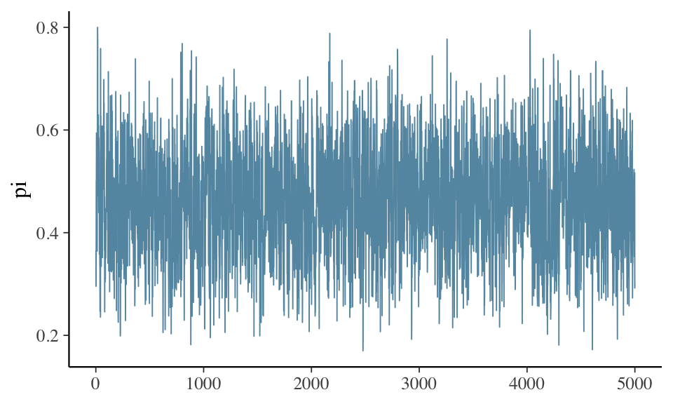

```r
# Adapt this code for the other chains
library(bayesplot)
mcmc_trace(chain_1)
```

**R Exercise: autocorrelation plots**

Though Markov chains are inherently dependent, we’d like them to behave as randomly as possible (random samples are great!). That is, we’d like the *autocorrelation* in the chain values to fade quickly. To assess this goal, compare and contrast *autocorrelation plots* for our 3 chains. These plot the autocorrelation (y-axis) for pairs of chain values at each lag (x-axis): the autocorrelation between chain values that are 1 step apart (lag 1), chain values that are 2 steps apart (lag 2), etc.

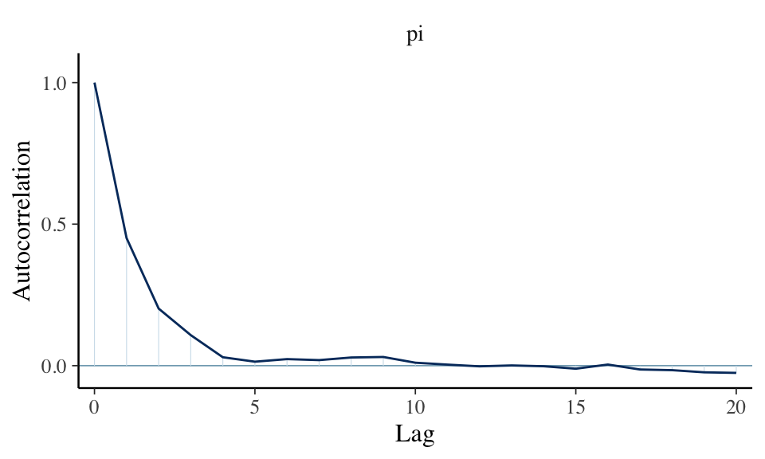

```r
# Adapt this code for the other chains
mcmc_acf(chain_1)
```

**R Exercise: density plots**

Whereas trace plots illuminate a Markov chain’s *longitudinal* behavior, we also want to examine the distribution of values that a chain visits along its tour. Compare and contrast *density plots* of the three Markov chains. For illustrative purposes only, we’ll compare our Markov chain density plots to the actual Beta(11, 13) posterior. (In practice, we would only simulate a posterior if we didn’t know what it was, thus wouldn’t have this luxury!)

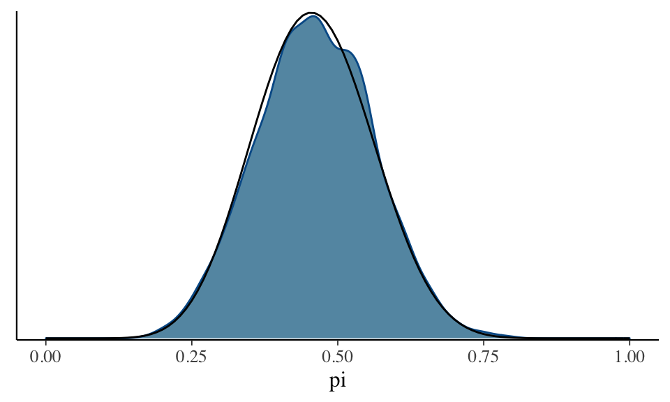

```r
# Adapt this code for the other chains
library(ggplot2)
mcmc_dens(chain_1) +
  stat_function(fun = dbeta, args = list(11, 13)) +
  xlim(0, 1)
```

**Question:**

- Reflecting upon the diagnostics, which of the 3 chains do you prefer?
- Even if we hadn’t had the luxury of comparing the density plots to the actual posterior, how might you have come to this conclusion from the chain plots alone?
- What are the main drawbacks of the two chains that you don’t prefer?

# Posterior approximation

We hope you agree that `chain_1` is best! `chain_2` is too short, or the sample too small, to provide an accurate approximation of the posterior. `chain_3` has too much autocorrelation, thus struggles to explore the entire range of posterior plausible values in a manner proportional to their plausibility. Let’s use `chain_1` to *approximate* various features of the posterior model.

**R Exercise: Posterior Means**

Per the above `summarize_beta_binomial()` output, the actual Beta(11, 13) posterior mean estimate of $\pi$ is 0.4583. That is, we expect that roughly 45.83% of films pass the Bechdel test. Use your `chain_1` values to *estimate* this posterior mean. How close is it?!

```r
# Approximate the posterior mean from chain_1
# If you get stuck, scroll down
```

```r
# Answer: We can approximate the posterior mean
# by the mean of our Markov chain sample!
library(dplyr)
chain_1 %>%
  summarize(mean(pi))
```

```
##    mean(pi)
## 1 0.4611644
```

**R Exercise: Posterior Credible Intervals**

The *actual* 80% posterior credible interval for $\pi$ is (0.330, 0.589). That is, there’s an 80% chance that somewhere between 33% and 58.9% of films pass the Bechdel test:

```r
qbeta(c(0.1, 0.9), 11, 13)
```

```
## [1] 0.3297127 0.5885312
```

Use your `chain_1` values to *estimate* this credible interval. How close is it?!

```r
# Approximate the 80% posterior credible interval from chain_1
# If you get stuck, scroll down
```

```r
# Answer: We can approximate the posterior quantiles
# by the quantiles of our Markov chain sample!
chain_1 %>%
  summarize(quantile(pi, c(0.1, 0.9)))
```

```
##   quantile(pi, c(0.1, 0.9))
## 1                 0.3315308
## 2                 0.5905748
```

**R Exercise: Posterior Probabilities**

Your friend claims that more than 50% of films pass the Bechdel test. The *actual* posterior probability of this claim is 0.339, pretty slim:

```r
pbeta(0.5, 11, 13, lower = FALSE)
```

```
## [1] 0.3388197
```

Use your `chain_1` values to *estimate* this posterior probability. How close is it?!

```r
# Approximate the posterior probability that pi > 0.5
# If you get stuck, scroll down
```

```r
# Answer: We can approximate the posterior probability
# by the proportion of our Markov chain sample values
# that fall above 0.5
chain_1 %>%
  summarize(mean(pi > 0.5))
```

```
##   mean(pi > 0.5)
## 1         0.3578
```

**CHALLENGE: Posterior Prediction**

Suppose you watch *10* more recent films. Let Y be the number of these that pass the Bechdel test.

- Based on the posterior model of $\pi$, what values do you *think* Y might take? What is the most likely value? What’s the range of values?
- Use `chain_1` to simulate, plot, and discuss a *posterior predictive model* of Y. Hints and a solution are below.

Hints:

- Y has a Bin(10, $\pi$) model
- `chain_1` includes 5000 posterior plausible values of `pi`
- for a full range of possible outcomes, simulate one outcome Y from each `pi` value
- `rbinom(5000, size = ___, prob = __)`
- scroll down for a solution

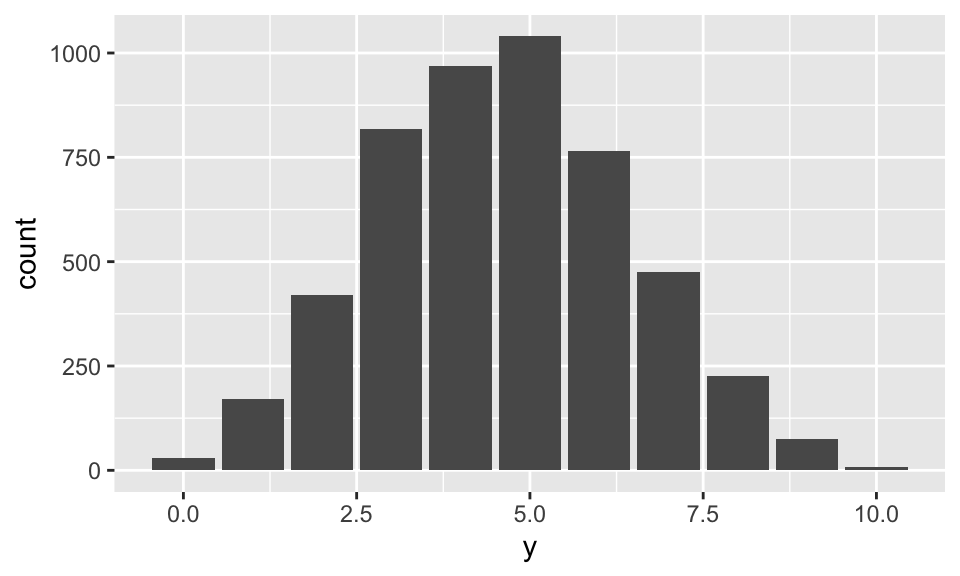

```r
# A solution
chain_1 %>%
  mutate(y = rbinom(5000, size = 10, prob = pi)) %>%
  ggplot(aes(x = y)) +
    geom_bar()
```

# OPTIONAL: rstan

IF you’re curious about how we simulated these chains, read on. If not, no problem! In these last exercises, we’ll explore how to simulate the Beta-Binomial model in `rstan`. There are two essential steps to all **rstan** analyses:

1. define the Bayesian model structure in **rstan** notation; then
2. simulate the posterior.

**R Exercise: step 1**

Run the chunk below which defines our Beta-Binomial model structure (the prior and data). Notice that this depends upon three aspects:

- `data`  
  Data Y is the observed number of successes in 20 trials. Since **rstan** isn’t a mind reader, we must specify that Y is an *integer* between 0 and 20.
- `parameters`  
  The model depends upon parameter $\pi$, or `pi` in **rstan** notation. We must specify that $\pi$ can be any *real* number between 0 and 1.
- `model`  
  The model is defined by the Bin(20, $\pi$) model for data Y and the Beta(2, 2) prior for $\pi$. We specify these using `binomial()` and `beta()`.

```r
# STEP 1: DEFINE the model
library(rstan)
bb_model <- "
  data {
    int<lower = 0, upper = 20> Y;
  }
  parameters {
    real<lower = 0, upper = 1> pi;
  }
  model {
    Y ~ binomial(20, pi);
    pi ~ beta(2, 2);
  }
"
```

**R Exercise: step 2**

In **step 2**, we *simulate* the posterior using the `stan()` function. *Very* loosely speaking, `stan()` designs and runs an MCMC algorithm to produce an approximate sample from the Beta-Binomial posterior. What type of information do we have to provide here?!

```r
chain_1 <- stan(model_code = bb_model, data = list(Y = 9),
                chains = 1, iter = 5000*2, seed = 84735)
```

**R Exercise: diagnostics**

Check out some `chain_1` plots. Looks good!

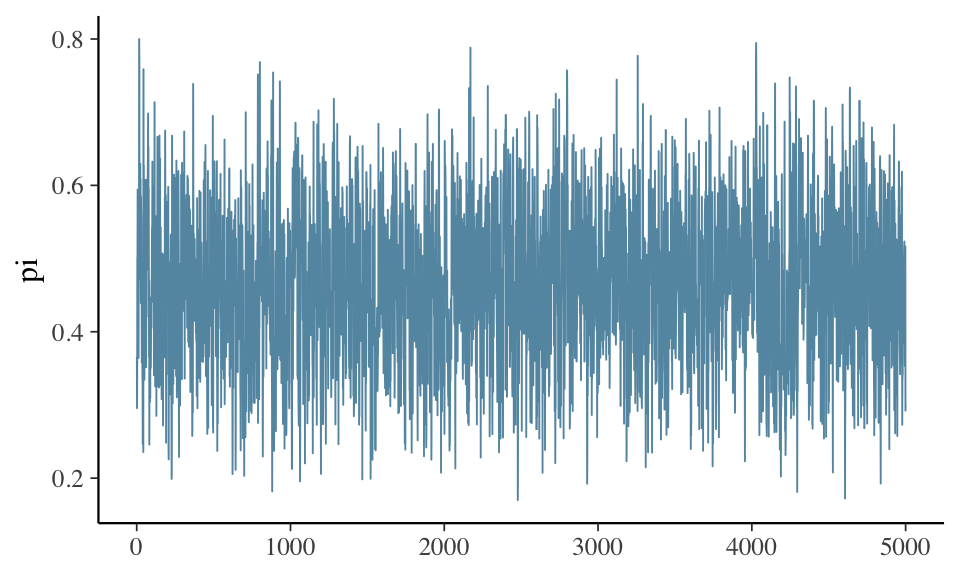

```r
mcmc_trace(chain_1)
```

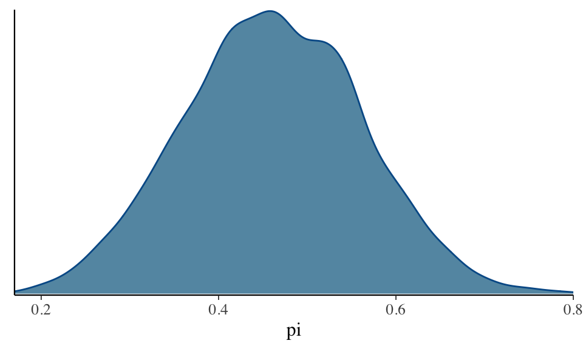

```r
mcmc_dens(chain_1)
```

**R Exercise: play around**

Play around with the `bb_sim` simulation step.

```r
new_chain <- ???
mcmc_trace(new_chain)
mcmc_dens_overlay(new_chain)
```

- Try increasing the number of `chains` from 1 to 4. What do you think is going on here? What might be the advantages to using 4 chains?
- Try increasing `iter` from `5000*2` to `10000*2`. Construct some plots and explain what this does.
- Switch up the model! How can we change the syntax to simulate the posterior model of $\pi$ if we used a Beta(1,4) prior and observed that 23 of 50 films passed the Bechdel test?